# Anime

# Visualización final de los clusters

Finalmente, se combinan las coordenadas del PCA con la asignación de clusters para visualizar la solución k = 5 dentro del espacio PC1-PC2.

```r
library(dplyr)
library(ggplot2)

# Unir coordenadas PCA con los clusters
datos_grafico_k5 <- coordenadas_pca %>%
  left_join(
    datos_clustering %>%
      select(id, cluster_k5),
    by = "id"
  )

head(datos_grafico_k5)
```

```
##         PC1        PC2        PC3     id cluster_k5
## 1 -3.989868  0.2141666 -0.6308527  16498          1
## 2 -3.861813  0.1222891 -0.7349491 101922          1
## 3 -3.888376  0.2083270 -0.6649460 113415          1
## 4 -4.020403 -0.1295530 -0.6451899   1535          1
## 5 -3.244542  0.4714414 -1.0940431  21459          1
## 6 -4.714399 -1.1092860 -0.2222821  11061          1
```

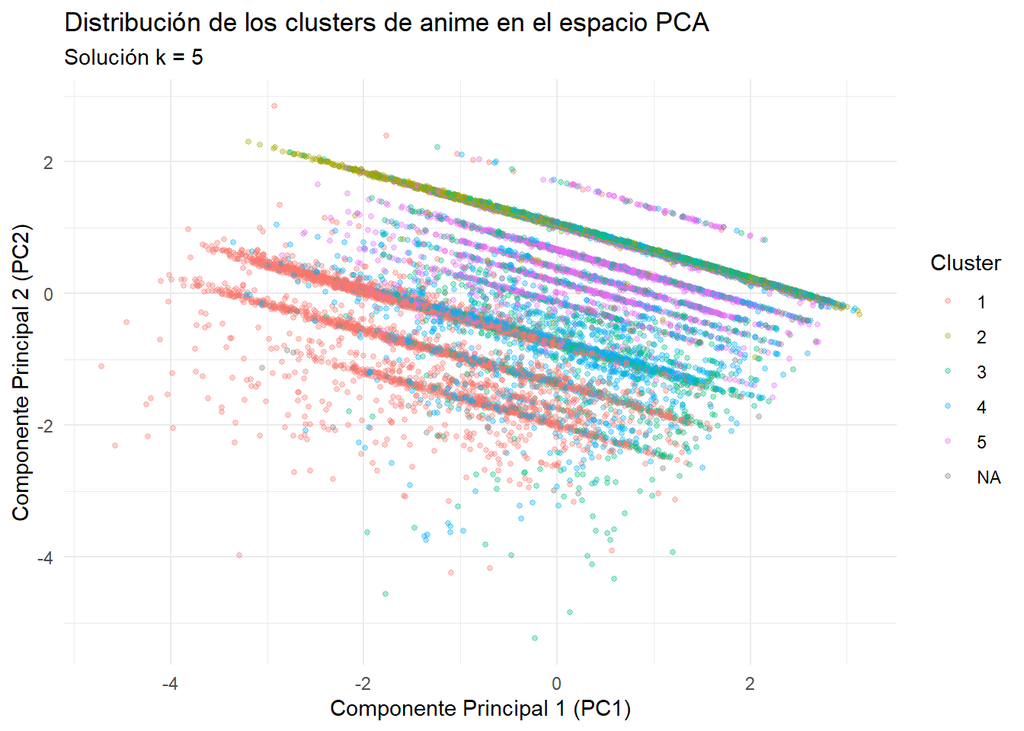

```r
# Visualizar los clusters en el espacio PCA
ggplot(
  datos_grafico_k5,
  aes(
    x = PC1,
    y = PC2,
    color = factor(cluster_k5)
  )
) +
  geom_point(
    alpha = 0.35,
    size = 1
  ) +
  labs(
    title = "Distribución de los clusters de anime en el espacio PCA",
    subtitle = "Solución k = 5",
    x = "Componente Principal 1 (PC1)",
    y = "Componente Principal 2 (PC2)",
    color = "Cluster"
  ) +
  theme_minimal()
```

La visualización final permite observar la distribución de los cinco clusters en las dos principales dimensiones del PCA. Se aprecia cierta superposición entre grupos, lo cual es consistente con el valor de silhouette obtenido.

Es importante considerar que el PCA utiliza únicamente las tres variables cuantitativas, mientras que el clustering incorpora además los indicadores de género y formato. Por ello, esta gráfica debe interpretarse como una proyección visual de los clusters, y no como una representación completa de todas las variables utilizadas por k-means.

En conjunto, el análisis permite identificar diferentes perfiles de anime a partir de la combinación de duración, valoración, popularidad, género y formato. El PCA facilita la reducción y visualización de las variables cuantitativas, mientras que el clustering permite complementar esta visión mediante agrupaciones construidas a partir del conjunto ampliado de características.